# R将非正态转化为正态

韩大云

2020-01-05

# 适用场景

在处理数据时偶尔会遇到“这组数据非正态”的问题，本文就以下关键点进行详解：  
1. 处理数据  
2. 画概率密度图分析正态性  
3. 将非正态转化为正态  
4. 可视化散点图、回归线

用到的包：  
1. ‘carData’ R自带数据集  
2. ‘ggplot2’ 可视化  
3. ‘MASS’ 进行box-cox转换  
4. ‘moments’ 进行偏度锋度计算

# 实例

## 载入数据集

- 包 `carData` 中有一个叫 `Leinhardt` 的数据文件。该文件为105个国家（行数）在1970年代左右的数据。该文件共有4个变量（列数）：`income` 表示该国人均收入水平；`infant` 表示该国每1000个新生儿中的儿童死亡率；`region` 表示该国所属地区；`oil` 表示该国是否为石油输出国。

```r
library('carData') ## 载入carData
df1 <- Leinhardt ## 载入数据集
```

## 处理缺失值

- 数据中存在一些缺失值，占比不大，下面直接去掉这些缺失值。

```r
# 2. 去掉缺失值
df1 <- na.omit(df1)
```

## 概率密度图

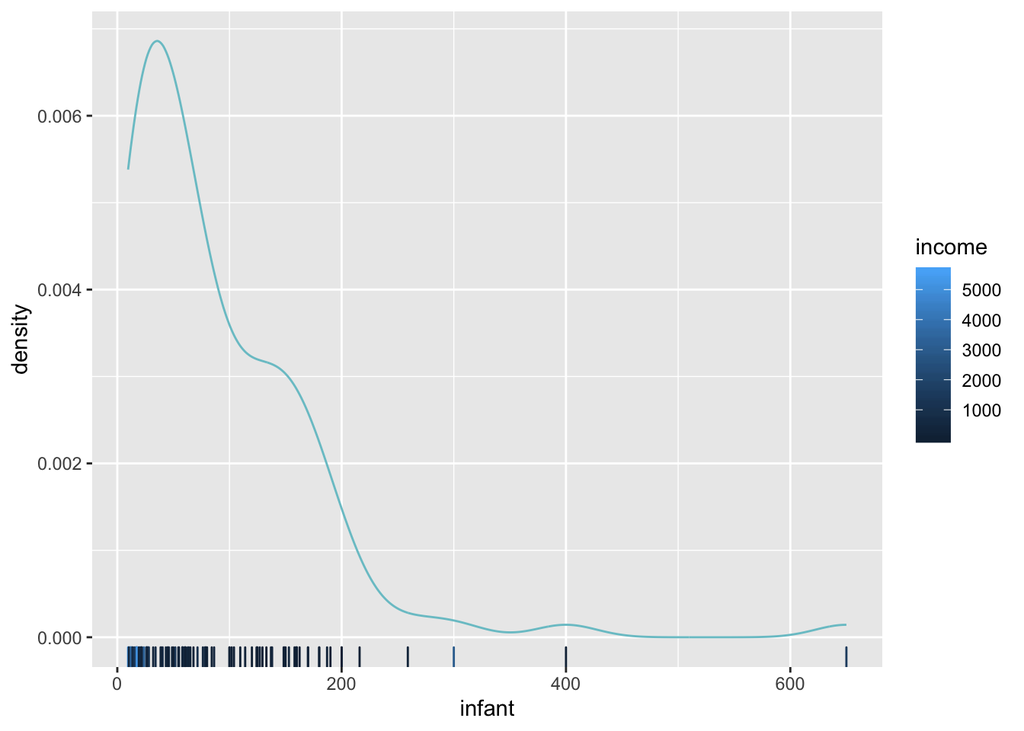

```r
# 3. 画概率密度图、分析正太性
require(ggplot2)
ggplot(df1, aes(x = infant)) +
  geom_line(colour = "cadetblue3", stat = "density") +
  geom_rug(aes(colour = income), sides = "b")
```

## 转化非正态为正态

- 对这两列数据进行转化。

  **转化前，记income为X，infant为Y；转化后后分别为X，Ylam。**

```r
# 以下用Box-Cox方法进行正态转化
# 准备数据集
X <- df1[,1]
Y <- df1[,2]
data <- as.data.frame(cbind(X,Y))
lm.sol<-lm(Y~X)

# 1. 加载MASS包
require(MASS) ## 基于此包进行box-cox转换
require(moments) ## 此包可进行偏度锋度计算
```

```r
# 2. 作图, 共4张
op <- par(mfrow=c(2,2), mar=.4+c(4,4,1,1), oma= c(0,0,2,0))

# 2.1 第1张, 残差与预测散点图
plot(fitted(lm.sol), resid(lm.sol),
     cex=1.2, pch=21, col="red", bg="orange",
     xlab="Fitted Value", ylab="Residuals") ## Fitted Value拟合值，Residuals残差

# 2.2 第2张, 进行Box-Cox转换，确定λ值
b <- boxcox(lm.sol, data=data)
lambda <- b$x
lik <- b$y
bc <- cbind(lambda, lik)
bc[order(-lik),] ## 结果λ=-0.18时对数似然函数达到最大，因此λ取值-0.18
```

```
##             lambda       lik
##   [1,] -0.18181818 -200.9837
##   [2,] -0.22222222 -201.0083
##   [3,] -0.14141414 -201.1243
##   [4,] -0.26262626 -201.1980
##   [5,] -0.10101010 -201.4300
##   [6,] -0.30303030 -201.5527
##   [7,] -0.06060606 -201.9005
##   [8,] -0.34343434 -202.0721
##   [9,] -0.02020202 -202.5357
##  [10,] -0.38383838 -202.7557
##  [11,]  0.02020202 -203.3354
##  [12,] -0.42424242 -203.6028
##  [13,]  0.06060606 -204.2991
##  [14,] -0.46464646 -204.6127
```

[output cut: 86 more lines]

```r
# Box-Cox变换后, 作回归分析
lambda<- -0.18; Ylam<- (Y^lambda-1)/lambda
lm.lam<-lm(Ylam~X); summary(lm.lam)
```

```
##
## Call:
## lm(formula = Ylam ~ X)
##
## Residuals:
##      Min       1Q   Median       3Q      Max
## -1.06229 -0.18702  0.02644  0.21944  1.17113
##
## Coefficients:
##               Estimate Std. Error t value Pr(>|t|)
## (Intercept)  3.067e+00  4.334e-02  70.768  < 2e-16 ***
## X           -2.234e-04  2.467e-05  -9.056 1.25e-14 ***
## ---
## Signif. codes:  0 '***' 0.001 '**' 0.01 '*' 0.05 '.' 0.1 ' ' 1
##
## Residual standard error: 0.3542 on 99 degrees of freedom
## Multiple R-squared:  0.4531, Adjusted R-squared:  0.4476
## F-statistic: 82.02 on 1 and 99 DF,  p-value: 1.25e-14
```

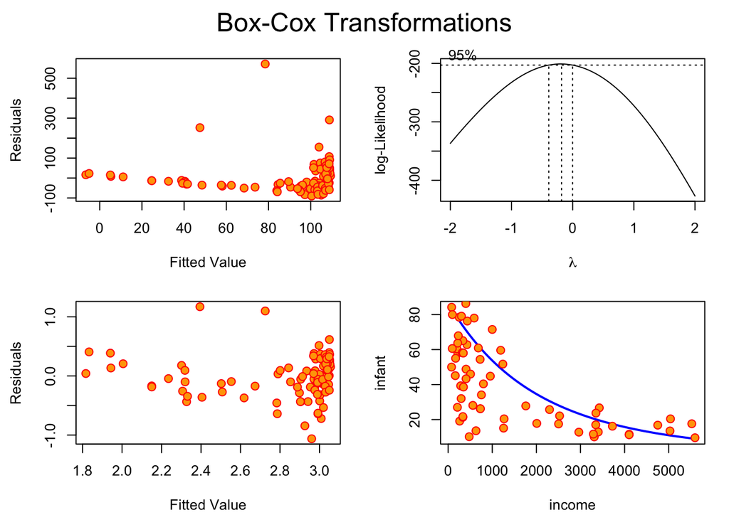

```r
# 2.3 第3张, 变换后残差与预测散点图
plot(fitted(lm.lam), resid(lm.lam),
     cex=1.2, pch=21, col="red", bg="orange",
     xlab="Fitted Value", ylab="Residuals")

# 2.4 第4张, 回归曲线和相应的散点
beta0<-lm.lam$coefficients[1]
beta1<-lm.lam$coefficients[2]
curve((1+lambda*(beta0+beta1*x))^(1/lambda),
      from=min(X), to=max(X), col="blue", lwd=2,
      xlab="income", ylab="infant")
points(X,Y, pch=21, cex=1.2, col="red", bg="orange")
mtext("Box-Cox Transformations", outer = TRUE, cex=1.5)
```

```r
par(op)
```

## 作散点图并添加回归线

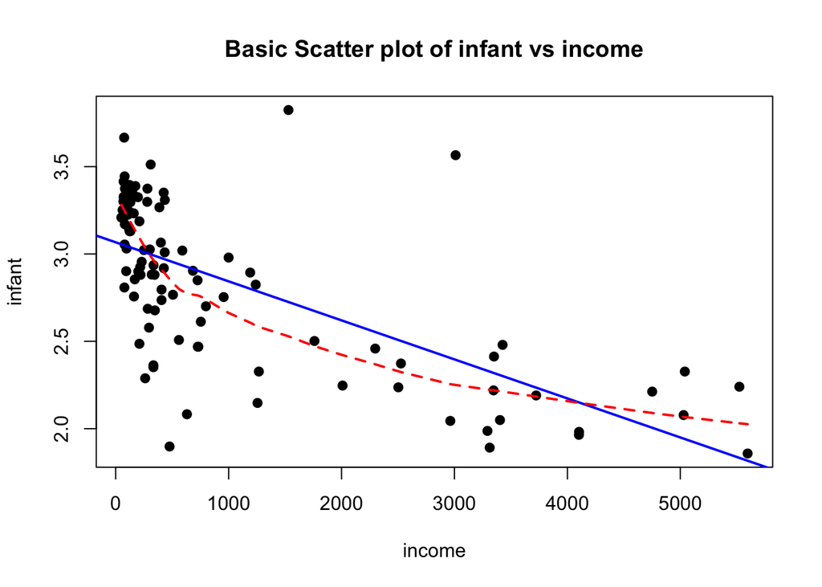

```r
plot(X,Ylam,main="Basic Scatter plot of infant vs income",xlab="income",ylab="infant",pch=19)
abline(lm(Ylam~X),col="blue",lwd=2,lty=1)
lines(lowess(X,Ylam),col="red",lwd=2,lty=2)
```